# Airline_Data_Challenge_Program

Seth Carter

2025-06-05

#Preparation

`**Data Loading, Preprocessing, and Munging**`

```r
##To Begin, Loading Provided csv datasets given working directory "Airline_Data_Challenge" and .Rproj "Airline_Data_Challenge.Rproj"

#In principle, any new file names uploaded to the folders under "data" and "raw" can be substituted for reusability. Circumvents hard coding of file paths.


library(readr)
library(here)
flights <- read_csv(here("data", "raw", "Flights.csv"))
tickets <- read_csv(here("data", "raw", "Tickets.csv"))
airports <- read_csv(here("data", "raw", "Airport_Codes.csv"))
#Firstly, it can be immediately observed in RStudio that 'FL_DATE' (Flight Dates) from 'flights' df are not uniformly formatted, 'AIR_TIME' (flights df) from 'flights' df includes negative/missing values for both cancelled and non-cancelled flights. Additionally, 'ITIN_FARE' in the 'tickets' df includes some character values with '$', and 'flights' includes important numeric information in AIR_TIME and DISTANCE as characters. This should be addressed in current and future cleaning process workflows. Various column values from airports df are frequently missing.


#For converting any character observations with '$' in 'ITIN_FARE' , tickets to numeric to avoid losing relevant data, we may use the following general function:

convert_character_values_to_numeric <- function(df, cols) {
  for (col in cols) {
    # Removing anything that's not a digit, decimal point, or minus sign
    df[[col]] <- gsub("[^0-9.-]", "", df[[col]])
    # Convert the cleaned string to numeric
    df[[col]] <- as.numeric(df[[col]])
  }
  return(df)
}

#Apply new function to 'ITIN_FARE' column in 'tickets' dataframe:

tickets <- convert_character_values_to_numeric(tickets, "ITIN_FARE")

#Applying the function additionally to relevant flights dataframe columns:
  #Note, 'TWO' for AIR_TIME in flights column is unclear in whether it may have referred to hours or minutes, and should likely be removed as unclear. Similarly, it is unclear whether DISTANCE values of 'Hundred' and 'Twenty' were intended to correspond to precise 'mile' values, and the design decision may be made to remove rather than convert them on assumption.

flights <- convert_character_values_to_numeric(flights, "AIR_TIME")
flights <- convert_character_values_to_numeric(flights, "DISTANCE")


#Additionally, visual inspect of minimum values for particular flight data for "AIR_TIME" provided indicates unrealistic negative values, 0 values, and reported flight times of 6 minutes or under that appear to correspond to either reporting error (reported as number of hours rather than minutes) or an unclear bottom coding. Raw DISTANCE also includes negative values and values of 2 or below that may be due to reporting error or an unclear coding. Given lack of additional context, it may be reasonable to exclude these values for the time being from analysis.

library(dplyr)
remove_low_values <- function(df, cols, threshold = 6) {
  df %>%
    mutate(across(
      all_of(cols),
      ~ifelse(.x <= threshold, NA, .x)
    ))
}

#Note: 'threshold' may be easily updated for alternative use given distinct sampling

#Applying function to 'AIR_TIME' and 'DISTANCE' columns in flights df:

flights <- remove_low_values(flights, cols = c("AIR_TIME", "DISTANCE"), threshold = 6)



#For the 'FL_DATE'column, it can be seen that raw data is primarily in conventional date format 'yyyy-mm-dd' but has some deviating values in 'm/d/yyyy'. For reusability in case this inconsistency is present across other quarters for future queries, where it may also appear as 'mm/dd/yyyy' and 'mm/d/yyyy', or even 'm/d/yy' 'mm/dd/yy', and 'm/dd/yy';  we may write a function to convert all of these possible formats into 'yyyy-mm-dd' using the 'anytime' package. 'anytime' is chosen here in lieu of 'lubridate' or manual format parsing to handle a wider range of future raw date inputs for future applications on the data.

library(anytime)

convert_flight_dates <- function(df, date_col = "FL_DATE") {
  # Make sure the column is character
  raw_dates <- as.character(df[[date_col]])

  # Let anytime handle various formats
  parsed_dates <- anytime::anydate(raw_dates)

  # Replace the column in the dataframe
  df[[date_col]] <- parsed_dates
  return(df)
}


#Applying convert_flight_dates function to 'FL_DATE' in the flights df to establish consistent date format:

flights <- convert_flight_dates(flights, "FL_DATE")
#For categorical indicators, we may write a function that lists all unique values to ensure thorough data cleaning:

list_unique_values <- function(df, col_name) {
  unique_values <- unique(df[[col_name]])
  return(unique_values)
}

#Applying to Cancelled Flights ('CANCELLED'):

list_unique_values(flights, 'CANCELLED')
```

```
## [1] 0 1
```

```r
#Output is uniformly 0 or 1.

#Given instruction to limit analysis to non-cancelled flights, we may now write a reusable function with a raw flight dataframe as an input, and a non-cancelled flight subset as an output.'CANCELLED' values are uniformly binary

remove_cancelled_flights <- function(df, status_col = 'CANCELLED', cancelled_value = 1) {
  df <- df[df[[status_col]] != cancelled_value, ]
  return(df)
}

#Applying to current flights dataset:

non_cancelled_flights <- remove_cancelled_flights(flights, 'CANCELLED')


#Investigating airports df, instructions are to only consider medium and large airports.

#Examining raw value types in airports df:

list_unique_values(airports, 'TYPE')
```

```
## [1] "heliport"       "small_airport"  "closed"         "seaplane_base"
## [5] "balloonport"    "medium_airport" "large_airport"
```

```r
#"medium_airport" and "large_airport" are among category names and may be subsetted for:

medium_large_airports_only <- function(df, type_col = 'TYPE', medium_large_entries = c("medium_airport", "large_airport")) {
  df <- df[df[[type_col]] %in% medium_large_entries, ]
  return(df)
}

medium_large_airports <- medium_large_airports_only(airports, 'TYPE')

#For tickets df, asked to only consider round trips.

#Identifying value ranges for tickets df:

list_unique_values(tickets, 'ROUNDTRIP')
```

```
## [1] 1 0
```

```r
#Output is uniformly 0 or 1.

#Writing a function to subset for roundtrips only:

roundtrips_only <- function(df, roundtrip_col = 'ROUNDTRIP', roundtrip_value = 1) {
  df <- df[df[[roundtrip_col]] == roundtrip_value, ]
  return(df)
}

#Apply function to current tickets df:

roundtrip_tickets <- roundtrips_only(tickets, roundtrip_col = 'ROUNDTRIP')


#Note that although there is incomplete data for some medium-sized, large-sized airports for IATA code, raw ticket and round-trip ticket dataframes do not include any missing arrival/destination airport codes. For the present task, we may determine if roundtrip-ticket data contains any destinations/origins not present in the full airport dataframe IATA codes. If only codes presently recorded in the airports dataframe exist in the tickets data, we may exclude airports with missing IATA codes as not having relevant data for inclusion in the final recommendation.

#Writing reusable function for comparing column value presence across dataframes:

values_in_df_2_not_in_df_1 <- function(df1, col1, df2, col2) {
  values_df1 <- unique(df1[[col1]])
  values_df2 <- unique(df2[[col2]])

  missing_values <- setdiff(values_df1, values_df2)
  return(missing_values)
}

airports_in_roundtrip_tickets_df_not_in_airports_df <- values_in_df_2_not_in_df_1(roundtrip_tickets, "ORIGIN", airports, "IATA_CODE")
print(airports_in_roundtrip_tickets_df_not_in_airports_df)
```

```
## character(0)
```

```r
#Output: character(0), implying that only airports with non-missing IATA_CODE have roundtrip data in the raw files

#Using function with 'DESTINATION' instead of 'ORIGIN' to be certain:

airports_in_roundtrip_tickets_df_not_in_airports_df <- values_in_df_2_not_in_df_1(roundtrip_tickets, "DESTINATION", airports, "IATA_CODE")
print(airports_in_roundtrip_tickets_df_not_in_airports_df)
```

```
## character(0)
```

```r
#Output: character(0)

#Given environment, writing function filtering for medium-sized and large-sized airports without missing data for IATA_CODE:

remove_obs_missing_in_col <- function(df, col_name) {
  df <- df[!is.na(df[[col_name]]), ]
  return(df)
}

#Apply function to medium_large_airports for 'IATA_CODE':

medium_large_airports_with_IATA_CODE <- remove_obs_missing_in_col(medium_large_airports, 'IATA_CODE')

#Considering only routes between medium/large airport per instructions, should write function to filter relevant 'flights' and 'tickets' observations to those with medium/large airports for 'ORIGIN' and 'DESTINATION':

#Function to filter flights and roundtrip tickets for airport 'ORIGIN' and 'DESTINATION' codes that correspond to medium/large airports (or any other dataframe of airport codes used as a reference):

filter_airport_pairs <- function(reference_df, reference_col, target_df, origin_col = "ORIGIN", destination_col = "DESTINATION") {

  valid_codes <- unique(reference_df[[reference_col]])

  filtered_df <- target_df[target_df[[origin_col]] %in% valid_codes &
    target_df[[destination_col]] %in% valid_codes, ]

  return(filtered_df)
}

#Applying function to roundtrip tickets dataframe, and flights dataframe given medium/large airports with codes:

medium_large_airport_roundtrip_tickets <- filter_airport_pairs(medium_large_airports_with_IATA_CODE, "IATA_CODE", roundtrip_tickets)

medium_large_airport_noncancelled_flights <- filter_airport_pairs(medium_large_airports_with_IATA_CODE, "IATA_CODE", non_cancelled_flights)

medium_large_airport_flights <- filter_airport_pairs(medium_large_airports_with_IATA_CODE, "IATA_CODE", flights)


#Given the cleaned sample of roundtrip tickets, we may write a function to calculate the total expected itinerary fare per flight from roundtrip tickets conditional on the itinerary being left uncancelled:

calculate_total_itinerary_fare <- function(df, fare_col, passengers_col, new_col = "TOTAL_ITIN_FARE") {
  df[[new_col]] <- as.numeric(df[[fare_col]]) * as.numeric(df[[passengers_col]])
  return(df)
}

#Applying to current medium_large_airport_roundtrip_tickets dataframe columns:

medium_large_airport_roundtrip_tickets <- calculate_total_itinerary_fare(df = medium_large_airport_roundtrip_tickets, fare_col = "ITIN_FARE", passengers_col = "PASSENGERS", new_col = "TOTAL_ITIN_FARE")



#Based on sample and assuming random or close-to-random properties of the sample selection process yielding the raw 'tickets' dataframe, we may calculate reliable summary statistics for passenger number (PASSENGERS), itinerary fare per passenger (ITIN_FARE), and total itinerary fare (TOTAL_ITIN_FARE) by each unique combination of 'ORIGIN' and 'DESTINATION' reflected in the roundtrip tickets data (long format preferred):



library(dplyr)
library(tidyr)

summarize_long_by_origin_dest <- function(df, cols_to_summarize) {
  # Validate numeric columns
  valid_cols <- cols_to_summarize[cols_to_summarize %in% names(df)]
  numeric_cols <- valid_cols[sapply(df[valid_cols], is.numeric)]

  if (length(numeric_cols) == 0) {
    stop("No numeric columns to summarize.")
  }

  df %>%
    group_by(ORIGIN, DESTINATION) %>%
    summarise(
      count = n(),  # add count of rows in each group
      across(
        all_of(numeric_cols),
        list(
          mean = ~mean(.x, na.rm = TRUE),
          median = ~median(.x, na.rm = TRUE),
          min = ~min(.x, na.rm = TRUE),
          max = ~max(.x, na.rm = TRUE),
          sd = ~sd(.x, na.rm = TRUE)
        ),
        .names = "{.col}_{.fn}"
      ),
      .groups = "drop"
    ) %>%
    rename(OBSERVATIONS_count = count) %>%  # consistent naming
    pivot_longer(
      cols = -c(ORIGIN, DESTINATION),
      names_to = c("variable", "statistic"),
      names_pattern = "^(.*)_(mean|median|min|max|sd|count)$",
      values_to = "value"
    )
}



#Applying the above function to summarize "PASSENGERS", "ITIN_FARE", and "TOTAL_ITIN_FARE" by roundtrip route in the medium_large_airports_roundtrip_tickets dataframe:

ticket_sample_summary <- summarize_long_by_origin_dest(medium_large_airport_roundtrip_tickets, cols_to_summarize = c("PASSENGERS", "ITIN_FARE", "TOTAL_ITIN_FARE"))
#The ticket_sample_summary now contains the data by Origin-Destination combination for count (or frequency) of sampled itinerary records, and the mean/median/maximum/minimum/standard deviation information within each combination for the number of passengers, fare per passenger, and total itinerary fare (passengers*fare per passenger)


#For the medium-large aiports flights dataframe, we may obtain similar information by Origin-Destination combination and assume that technical flight data such as cancellation rate and occupancy remain relevant to the roundtrips being considered regardless of whether the flights recorded were roundtrips or non-roundtrips.

#In merging information from the  medium-large airport flights dataframe with the ticket_sample_summary dataframe, we may first consider computing statistics for each flight combination of format 'Origin - Airport 1' to 'Destination - Airport 2' with complementary statistics for 'Origin - Airport 2' to 'Destination - Airport 1' for medium_large_airport_noncancelled_flights. The sum of average DEP_DELAY divided by 2, ARR_DELAY divided by 2, AIR_TIME, and DISTANCE for both could be considered calculated 'Average Roundtrip' versions of each statistic. The sum of average OCCUPANCY_RATE for both flights divided by 2 could also yield an estimate for the average occupancy rate for the round-trip flight path. Prior to grouping, a count of the created route keys may be used to estimate 'observed round trip' frequencies based on the flights dataset.


library(dplyr)

compute_flight_roundtrip_stats <- function(df) {
  # 1. Define relevant variables
  roundtrip_vars <- c("DEP_DELAY", "ARR_DELAY", "AIR_TIME", "DISTANCE")
  occ_rate_var <- "OCCUPANCY_RATE"

  # 2. Create ROUTE_KEY (same for both directions) to join later
  df <- df %>%
    mutate(ROUTE_KEY = paste(pmin(ORIGIN, DESTINATION), pmax(ORIGIN, DESTINATION), sep = "_"))
```

```r
  # 3. Count total flights per ROUTE_KEY (regardless of direction)
  route_counts <- df %>%
    count(ROUTE_KEY, name = "OBSERVED_ROUND_TRIPS")

  # 4. Summarize each direction: one row per ORIGIN → DESTINATION
  dir_summary <- df %>%
    group_by(ORIGIN, DESTINATION, ROUTE_KEY) %>%
    summarise(
      across(
        all_of(roundtrip_vars),
        ~mean(.x, na.rm = TRUE),
        .names = "mean_{.col}"
      ),
      mean_OCCUPANCY_RATE = mean(.data[[occ_rate_var]], na.rm = TRUE),
      .groups = "drop"
    )

  # 5. Join each direction with its reverse
  roundtrip_joined <- dir_summary %>%
    inner_join(dir_summary, by = "ROUTE_KEY", suffix = c("_A", "_B")) %>%
    filter(ORIGIN_A == DESTINATION_B & DESTINATION_A == ORIGIN_B)

  # 6. Compute roundtrip stats
  roundtrip_stats <- roundtrip_joined %>%
    transmute(
      ROUTE_KEY,
      ROUNDTRIP = paste(ORIGIN_A, "↔", DESTINATION_A),
      AVG_DEP_DELAY = (mean_DEP_DELAY_A + mean_DEP_DELAY_B)/2,
      AVG_ARR_DELAY = (mean_ARR_DELAY_A + mean_ARR_DELAY_B)/2,
      AVG_AIR_TIME = mean_AIR_TIME_A + mean_AIR_TIME_B,
      AVG_DISTANCE = mean_DISTANCE_A + mean_DISTANCE_B,
      AVG_OCCUPANCY_RATE = (mean_OCCUPANCY_RATE_A + mean_OCCUPANCY_RATE_B) / 2
    ) %>%
    distinct()

  # 7. Join with route-level counts
  roundtrip_stats <- roundtrip_stats %>%
    left_join(route_counts, by = "ROUTE_KEY")

  return(roundtrip_stats)
}

#Applying function to medium_large_airport_flights

medium_large_airport_flight_roundtrip_stats <- compute_flight_roundtrip_stats(medium_large_airport_noncancelled_flights)
#The medium_large_airport_flight_roundtrip_stats dataframe still contains two copied observations per round trip, but removal of route_key duplicates ensures a single statistical row report per round trip:

remove_duplicates_by_column <- function(df, column, keep = c("first", "last")) {
  keep <- match.arg(keep)

  if (!column %in% names(df)) {
    stop(paste("Column", column, "not found in the dataframe."))
  }

  if (keep == "first") {
    df[!duplicated(df[[column]]), ]
  } else {
    df[!duplicated(df[[column]], fromLast = TRUE), ]
  }
}

#Applying to medium_large_airport_noncancelled_flight_roundtrip_stats

medium_large_airport_flight_roundtrip_stats <- remove_duplicates_by_column(medium_large_airport_flight_roundtrip_stats, column = "ROUTE_KEY")



#For additional information relevant to recommendation, we may also repeat the above process for the variable 'CANCELLED' alone on the medium_large_airport_flights dataframe to maintain information on cancellation frequency without including cancelled flights in the prior summary statistic reporting as requested

compute_flight_roundtrip_cancellation_freq <- function(df) {
  # 1. Define relevant variables
  roundtrip_vars <- c("CANCELLED")

  # 2. Create ROUTE_KEY (same for both directions) to join later
  df <- df %>%
    mutate(ROUTE_KEY = paste(pmin(ORIGIN, DESTINATION), pmax(ORIGIN, DESTINATION), sep = "_"))

  # 3. Summarize each direction: one row per ORIGIN → DESTINATION
  dir_summary <- df %>%
    group_by(ORIGIN, DESTINATION, ROUTE_KEY) %>%
    summarise(
      across(
        all_of(roundtrip_vars),
        ~mean(.x, na.rm = TRUE),
        .names = "mean_{.col}"
      ),
      .groups = "drop"
    )

  # 4. Join each direction with its reverse
  roundtrip_joined <- dir_summary %>%
    inner_join(dir_summary, by = "ROUTE_KEY", suffix = c("_A", "_B")) %>%
    filter(ORIGIN_A == DESTINATION_B & DESTINATION_A == ORIGIN_B)

  # 5. Compute roundtrip stats (sums of means or averages)
  roundtrip_cancelled_stats <- roundtrip_joined %>%
    transmute(
      ROUTE_KEY,
      ROUNDTRIP = paste(ORIGIN_A, "↔", DESTINATION_A),
      AVG_CANCELLED = mean_CANCELLED_A + mean_CANCELLED_B
    ) %>%
    distinct()

  return(roundtrip_cancelled_stats)
}


medium_large_airport_flight_roundtrip_cancelled_freq <- compute_flight_roundtrip_cancellation_freq(medium_large_airport_flights)
#Removing duplicates to report one frequency per roundtrip estimate:

medium_large_airport_flight_roundtrip_cancelled_freq <- remove_duplicates_by_column(medium_large_airport_flight_roundtrip_cancelled_freq, column = "ROUTE_KEY")


#For Merging Round Trip Statistics between flights statistics and tickets statistics, additionally transforming the relevant ticket sample summary by adding a matching ROUNDTRIP column:

add_roundtrip_column <- function(df) {
  if (!all(c("ORIGIN", "DESTINATION") %in% names(df))) {
    stop("The dataframe must contain 'ORIGIN' and 'DESTINATION' columns.")
  }

  df %>%
    mutate(
      ROUNDTRIP = paste(pmin(ORIGIN, DESTINATION), "↔", pmax(ORIGIN, DESTINATION))
    )
}

#Apply function to ticket_sample_summary dataframe:

ticket_sample_summary <- add_roundtrip_column(ticket_sample_summary)

#Given that Roundtrip technical flight estimates from flight records are inferred from single flights rather than necessarily reflecting existing round trip tickets, we may further simplify the available data by truncating medium_large_airport_flight_roundtrip_stats and medium_large_airport_flight_roundtrip_cancelled_freq by whether the inferred route is present in the ticket_sample_summary routes in the ROUNDTRIP column.

filter_by_column_val_in_other_df <- function(df1, df2, column_name) {
  if (!column_name %in% names(df1) || !column_name %in% names(df2)) {
    stop("Both dataframes must contain the specified column.")
  }

  df1 %>%
    filter(.data[[column_name]] %in% df2[[column_name]])
}

#Applying to dataframes:

medium_large_airport_flight_roundtrip_stats_w_ticket_data <- filter_by_column_val_in_other_df(medium_large_airport_flight_roundtrip_stats, ticket_sample_summary, "ROUNDTRIP")

medium_large_airport_flight_roundtrip_cancellation_freq_w_ticket_data <- filter_by_column_val_in_other_df(medium_large_airport_flight_roundtrip_cancelled_freq, ticket_sample_summary, "ROUNDTRIP")

#Similarly, we may only want to maintain roundtrip tickets for analysis that intersect with available flight data:

ticket_data_w_flight_stats <- filter_by_column_val_in_other_df(ticket_sample_summary, medium_large_airport_flight_roundtrip_stats, "ROUNDTRIP")
```

```r
#Given Correspondence we may write and apply a general function for merging the calculated roundtrip flight technical statistics with the calculated ticket variable statistics by corresponding ROUNDTRIP identifer:

library(dplyr)

append_roundtrip_stats <- function(long_df, roundtrip_stats_df) {
  # Check if 'ROUNDTRIP' column exists in both dataframes
  if (!("ROUNDTRIP" %in% names(long_df)) || !("ROUNDTRIP" %in% names(roundtrip_stats_df))) {
    stop("Both dataframes must contain a 'ROUNDTRIP' column.")
  }

  # Join roundtrip stats to the long-format dataframe
  long_df %>%
    left_join(roundtrip_stats_df, by = "ROUNDTRIP")
}

Merged_Ticket_Flight_Statistics_df <- append_roundtrip_stats(ticket_data_w_flight_stats, medium_large_airport_flight_roundtrip_stats_w_ticket_data)

#Function adding for each round trip based on arrival and departure airports a count of medium and large airports present in the round trip

library(dplyr)

add_airport_type_counts <- function(df_main, df_airport_types, airport_col1, airport_col2, type_col = "TYPE") {
  df_main %>%
    # Join airport types for each airport column
    left_join(df_airport_types, by = setNames("IATA_CODE", airport_col1)) %>%
    rename(TYPE_1 = !!type_col) %>%
    left_join(df_airport_types, by = setNames("IATA_CODE", airport_col2)) %>%
    rename(TYPE_2 = !!type_col) %>%
    # Count number of medium and large airports
    mutate(
      Medium_Airport = rowSums(across(c(TYPE_1, TYPE_2), ~.x == "medium_airport", .names = "medium_{col}"), na.rm = TRUE),
      Large_Airport = rowSums(across(c(TYPE_1, TYPE_2), ~.x == "large_airport", .names = "large_{col}"), na.rm = TRUE)
    ) %>%
    select(-TYPE_1, -TYPE_2)  # Clean up intermediate columns
}

#Apply function to Merged_Ticket_Flight_Statistics_df and medium_large_airports_with_IATA_CODE


Merged_Ticket_Flight_Statistics_w_Type <- add_airport_type_counts(df_main = Merged_Ticket_Flight_Statistics_df, df_airport_types = medium_large_airports_with_IATA_CODE, airport_col1 = "ORIGIN", airport_col2 = "DESTINATION")
```

#Task 1

`**The 10 busiest round trip routes in terms of number of round trip flights in the quarter. Exclude canceled flights when performing the calculation.**`

```r
#Taking the assumption that a 'Round Trip' flight may be considered as two ordinary flights following the provided 'Airport 1 -> Airport 2' 'Airport 2 -> Airport 1' format:

library(dplyr)

get_top_observed_roundtrips <- function(df, top_n = 10) {
  df %>%
    select(ROUNDTRIP, OBSERVED_ROUND_TRIPS) %>%
    distinct() %>%  # ensure each ROUNDTRIP only appears once
    arrange(desc(OBSERVED_ROUND_TRIPS)) %>%
    slice_head(n = top_n)
}

get_top_observed_roundtrips <- function(df, top_n = 10) {
  df %>%
    group_by(ROUNDTRIP) %>%
    slice_max(order_by = OBSERVED_ROUND_TRIPS, n = 1, with_ties = FALSE) %>%
    ungroup() %>%
    arrange(desc(OBSERVED_ROUND_TRIPS)) %>%
    slice_head(n = top_n)
}

#Apply function for the top 10 counts of flights across different round trips

top_observed_round_trips <- get_top_observed_roundtrips(Merged_Ticket_Flight_Statistics_w_Type, top_n = 10)


library(knitr)
library(kableExtra)
kable(top_observed_round_trips, "html", caption = "Top 10 Routes by Roundtrip Flight Count (To-and-From)") %>%
  kable_styling(
    bootstrap_options = c("striped", "hover", "condensed", "responsive"),
    full_width = FALSE,
    position = "center",
    font_size = 14
  )
```

Top 10 Routes by Roundtrip Flight Count (To-and-From)

| ORIGIN | DESTINATION | variable | statistic | value | ROUNDTRIP | ROUTE_KEY | AVG_DEP_DELAY | AVG_ARR_DELAY | AVG_AIR_TIME | AVG_DISTANCE | AVG_OCCUPANCY_RATE | OBSERVED_ROUND_TRIPS | NAME.x | ELEVATION_FT.x | CONTINENT.x | ISO_COUNTRY.x | MUNICIPALITY.x | COORDINATES.x | NAME.y | ELEVATION_FT.y | CONTINENT.y | ISO_COUNTRY.y | MUNICIPALITY.y | COORDINATES.y | Medium_Airport | Large_Airport |
| --- | --- | --- | --- | --- | --- | --- | --- | --- | --- | --- | --- | --- | --- | --- | --- | --- | --- | --- | --- | --- | --- | --- | --- | --- | --- | --- |
| LAX | SFO | OBSERVATIONS | count | 552 | LAX ↔︎ SFO | LAX_SFO | 18.4797205 | 15.7121513 | 113.95041 | 674 | 0.6490075 | 8340 | Los Angeles International Airport | 125 | NA | US | Los Angeles | -118.4079971, 33.94250107 | San Francisco International Airport | 13 | NA | US | San Francisco | -122.375, 37.61899948120117 | 0 | 2 |
| LGA | ORD | OBSERVATIONS | count | 660 | LGA ↔︎ ORD | LGA_ORD | 21.3364261 | 19.6443326 | 220.02756 | 1466 | 0.6491236 | 7156 | La Guardia Airport | 21 | NA | US | New York | -73.87259674, 40.77719879 | Chicago O’Hare International Airport | 672 | NA | US | Chicago | -87.9048, 41.9786 | 0 | 2 |
| LAS | LAX | OBSERVATIONS | count | 203 | LAS ↔︎ LAX | LAS_LAX | 10.1074012 | 6.9602621 | 89.66158 | 472 | 0.6494213 | 6511 | McCarran International Airport | 2181 | NA | US | Las Vegas | -115.1520004, 36.08010101 | Los Angeles International Airport | 125 | NA | US | Los Angeles | -118.4079971, 33.94250107 | 0 | 2 |
| JFK | LAX | OBSERVATIONS | count | 876 | JFK ↔︎ LAX | JFK_LAX | 8.5438078 | -1.8848299 | 630.49793 | 4950 | 0.6500723 | 6320 | John F Kennedy International Airport | 13 | NA | US | New York | -73.77890015, 40.63980103 | Los Angeles International Airport | 125 | NA | US | Los Angeles | -118.4079971, 33.94250107 | 0 | 2 |
| LAX | SEA | OBSERVATIONS | count | 464 | LAX ↔︎ SEA | LAX_SEA | 7.7424246 | 4.3530465 | 268.12911 | 1908 | 0.6544137 | 4999 | Los Angeles International Airport | 125 | NA | US | Los Angeles | -118.4079971, 33.94250107 | Seattle Tacoma International Airport | 433 | NA | US | Seattle | -122.308998, 47.449001 | 0 | 2 |
| BOS | LGA | OBSERVATIONS | count | 290 | BOS ↔︎ LGA | BOS_LGA | 19.6395320 | 14.2327688 | 86.08763 | 368 | 0.6508695 | 4820 | General Edward Lawrence Logan International Airport | 20 | NA | US | Boston | -71.00520325, 42.36429977 | La Guardia Airport | 21 | NA | US | New York | -73.87259674, 40.77719879 | 0 | 2 |
| HNL | OGG | OBSERVATIONS | count | 112 | HNL ↔︎ OGG | HNL_OGG | -0.3392479 | -0.1579871 | 45.62779 | 200 | 0.6476319 | 4794 | Daniel K Inouye International Airport | 13 | NA | US | Honolulu | -157.924228, 21.32062 | Kahului Airport | 54 | NA | US | Kahului | -156.429993, 20.8986 | 1 | 1 |
| PDX | SEA | OBSERVATIONS | count | 229 | PDX ↔︎ SEA | PDX_SEA | 7.5796401 | 7.7079301 | 63.29573 | 258 | 0.6500327 | 4774 | Portland International Airport | 31 | NA | US | Portland | -122.5979996, 45.58869934 | Seattle Tacoma International Airport | 433 | NA | US | Seattle | -122.308998, 47.449001 | 0 | 2 |
| ATL | MCO | OBSERVATIONS | count | 377 | ATL ↔︎ MCO | ATL_MCO | 6.1867444 | 1.4076177 | 125.60007 | 808 | 0.6494863 | 4707 | Hartsfield Jackson Atlanta International Airport | 1026 | NA | US | Atlanta | -84.428101, 33.6367 | Orlando International Airport | 96 | NA | US | Orlando | -81.30899810791016, 28.429399490356445 | 0 | 2 |
| ATL | LGA | OBSERVATIONS | count | 585 | ATL ↔︎ LGA | ATL_LGA | 11.3008983 | 5.4555516 | 220.27887 | 1524 | 0.6511018 | 4594 | Hartsfield Jackson Atlanta International Airport | 1026 | NA | US | Atlanta | -84.428101, 33.6367 | La Guardia Airport | 21 | NA | US | New York | -73.87259674, 40.77719879 | 0 | 2 |

#Task 2

`**The 10 most profitable round trip routes (without considering the upfront airplane cost) in the quarter. Along with the profit, show total revenue, total cost, summary values of other key components and total round trip flights in the quarter for the top 10 most profitable routes. Exclude cancelled flights from these calculations.**`

```r
  #Assuming that the noted airport operational costs are for the right to use the associated airports per round trip using each airport:

  #Consider: Total Profit = Expected Total Revenue - Expected Total Cost

  #Decomposing:
  #Total Profit Per Route = Total Expected Round Trips * [(Expected Occupancy Rate * 200 * (Mean Itinerary Fare per Passenger + 0.5 * Baggage Fee) - (FOMC Rate + DIO Rate) * Expected Miles per Round Trip  - Airport Operational Cost - Expected Departure Delay Cost - Expected Arrival Delay Cost]

  #Reusable Decomposition Given Prices/Costs

#Set Variables (Aliases) Equal to Price/Cost Parameters (may be edited for future changes to formula)
#All Rates/Costs in US Dollars ($)

Passenger_Cap = 200

FOMC_Rate = 8

DIO_Rate = 1.18

Fixed_Medium_Airport_Cost = 5000

Fixed_Large_Airport_Cost = 10000

Baggage_Fee = 70

Percent_Checked_Bag = 0.5

#Time Parameters in Minutes

Departure_Delay_Cost_Rate_Above_Threshold = 75

Arrival_Delay_Cost_Rate_Above_Threshold = 75

Delay_Threshold = 15


#Writing Function for Requested Profit, Revenue, and Total Cost as described:


compute_profit_revenue_cost_from_long <- function(df_long,
                                                  fare_var = "ITIN_FARE",
                                                  fare_stat = "mean",
                                                  Passenger_Cap = 200,
                                                  FOMC_Rate = 8,
                                                  DIO_Rate = 1.18,
                                                  Fixed_Medium_Airport_Cost = 5000,
                                                  Fixed_Large_Airport_Cost = 10000,
                                                  Baggage_Fee = 70,
                                                  Percent_Checked_Bag = 0.5,
                                                  Departure_Delay_Cost_Rate_Above_Threshold = 75,
                                                  Arrival_Delay_Cost_Rate_Above_Threshold = 75,
                                                  Delay_Threshold = 15) {
  # 1. Filter the fare data
  df_filtered <- df_long %>%
    filter(variable == fare_var & statistic == fare_stat) %>%
    select(ORIGIN, DESTINATION, variable, value) %>%
    pivot_wider(names_from = variable, values_from = value)

  # 2. Add in all other mean variables
  df_wide_extra <- df_long %>%
    filter(statistic == "mean" & variable != fare_var) %>%
    pivot_wider(names_from = variable, values_from = value) %>%
    distinct(ORIGIN, DESTINATION, .keep_all = TRUE)

  # 3. Join into one wide-format summary
  df_joined <- df_filtered %>%
    left_join(df_wide_extra, by = c("ORIGIN", "DESTINATION"))

  # 4. Compute PROFIT, REVENUE, COST in one step
  df_metrics <- df_joined %>%
    mutate(
      REVENUE = OBSERVED_ROUND_TRIPS *
        (AVG_OCCUPANCY_RATE * Passenger_Cap *
         (ITIN_FARE + (Percent_Checked_Bag * Baggage_Fee))),
      TOTAL_COST = OBSERVED_ROUND_TRIPS *
        ((FOMC_Rate + DIO_Rate) * AVG_DISTANCE +
         Fixed_Medium_Airport_Cost * Medium_Airport +
         Fixed_Large_Airport_Cost * Large_Airport +
         Departure_Delay_Cost_Rate_Above_Threshold * pmax(0, AVG_DEP_DELAY - Delay_Threshold) +
         Arrival_Delay_Cost_Rate_Above_Threshold * pmax(0, AVG_ARR_DELAY - Delay_Threshold)),
      PROFIT = REVENUE - TOTAL_COST,
      PROFIT_PER_ROUND_TRIP = (REVENUE - TOTAL_COST)/OBSERVED_ROUND_TRIPS
    ) %>%
    select(ORIGIN, DESTINATION, PROFIT, REVENUE, TOTAL_COST, PROFIT_PER_ROUND_TRIP)

  # 5. Join final metrics back to original long-format input
  df_long %>%
    left_join(df_metrics, by = c("ORIGIN", "DESTINATION"))
}


#Applying the Function

Merged_df_w_Prof_Rev_Cost <- compute_profit_revenue_cost_from_long(df_long = Merged_Ticket_Flight_Statistics_w_Type)


#Obtaining 10 Most Profitable Routes:

get_most_profitable_roundtrips <- function(df, top_n = 10) {
  df %>%
    group_by(ROUNDTRIP) %>%
    slice_max(order_by = PROFIT, n = 1, with_ties = FALSE) %>%
    ungroup() %>%
    arrange(desc(PROFIT)) %>%
    slice_head(n = top_n)
}


top_most_profitable_round_trips <- get_most_profitable_roundtrips(Merged_df_w_Prof_Rev_Cost, top_n = 10)


library(kableExtra)

kable(top_most_profitable_round_trips, "html", caption = "Top 10 Routes by Estimated Profitability") %>%
  kable_styling(
    bootstrap_options = c("striped", "hover", "condensed", "responsive"),
    full_width = FALSE,
    position = "center",
    font_size = 14
  )
```

Top 10 Routes by Estimated Profitability

| ORIGIN | DESTINATION | variable | statistic | value | ROUNDTRIP | ROUTE_KEY | AVG_DEP_DELAY | AVG_ARR_DELAY | AVG_AIR_TIME | AVG_DISTANCE | AVG_OCCUPANCY_RATE | OBSERVED_ROUND_TRIPS | NAME.x | ELEVATION_FT.x | CONTINENT.x | ISO_COUNTRY.x | MUNICIPALITY.x | COORDINATES.x | NAME.y | ELEVATION_FT.y | CONTINENT.y | ISO_COUNTRY.y | MUNICIPALITY.y | COORDINATES.y | Medium_Airport | Large_Airport | PROFIT | REVENUE | TOTAL_COST | … |
| --- | --- | --- | --- | --- | --- | --- | --- | --- | --- | --- | --- | --- | --- | --- | --- | --- | --- | --- | --- | --- | --- | --- | --- | --- | --- | --- | --- | --- | --- | --- |
| SLC | TWF | OBSERVATIONS | count | 4 | SLC ↔︎ TWF | SLC_TWF | 6.298156 | 0.8707803 | 66.78901 | 350 | 0.6686776 | 582 | Salt Lake City International Airport | 4227 | NA | US | Salt Lake City | -111.97799682617188, 40.78839874267578 | Joslin Field Magic Valley Regional Airport | 4154 | NA | US | Twin Falls | -114.487999, 42.4818 | 1 | 1 | 754489557 | 765089523 | 10599966 | … |
| JFK | LAX | OBSERVATIONS | count | 876 | JFK ↔︎ LAX | JFK_LAX | 8.543808 | -1.8848299 | 630.49793 | 4950 | 0.6500723 | 6320 | John F Kennedy International Airport | 13 | NA | US | New York | -73.77890015, 40.63980103 | Los Angeles International Airport | 125 | NA | US | Los Angeles | -118.4079971, 33.94250107 | 0 | 2 | 408441810 | 822028930 | 413587120 | … |
| JFK | SFO | OBSERVATIONS | count | 808 | JFK ↔︎ SFO | JFK_SFO | 15.353690 | 6.8902682 | 655.12140 | 5172 | 0.6498536 | 3721 | John F Kennedy International Airport | 13 | NA | US | New York | -73.77890015, 40.63980103 | San Francisco International Airport | 13 | NA | US | San Francisco | -122.375, 37.61899948120117 | 0 | 2 | 239332528 | 490520444 | 251187916 | … |
| SFO | EWR | OBSERVATIONS | count | 473 | EWR ↔︎ SFO | EWR_SFO | 21.497112 | 14.5427778 | 632.37058 | 5130 | 0.6499051 | 2424 | San Francisco International Airport | 13 | NA | US | San Francisco | -122.375, 37.61899948120117 | Newark Liberty International Airport | 18 | NA | US | Newark | -74.168701171875, 40.692501068115234 | 0 | 2 | 188337904 | 352153480 | 163815577 | … |
| ATL | CLT | OBSERVATIONS | count | 113 | ATL ↔︎ CLT | ATL_CLT | 5.770025 | -0.3014342 | 88.05380 | 452 | 0.6488660 | 3076 | Hartsfield Jackson Atlanta International Airport | 1026 | NA | US | Atlanta | -84.428101, 33.6367 | Charlotte Douglas International Airport | 748 | NA | US | Charlotte | -80.94309997558594, 35.2140007019043 | 0 | 2 | 154108935 | 228392366 | 74283431 | … |
| DCA | ORD | OBSERVATIONS | count | 247 | DCA ↔︎ ORD | DCA_ORD | 10.297696 | 6.4588294 | 185.21347 | 1224 | 0.6479212 | 3695 | Ronald Reagan Washington National Airport | 15 | NA | US | Washington | -77.037697, 38.8521 | Chicago O’Hare International Airport | 672 | NA | US | Chicago | -87.9048, 41.9786 | 0 | 2 | 152401529 | 267819731 | 115418202 | … |
| SFO | LAX | OBSERVATIONS | count | 616 | LAX ↔︎ SFO | LAX_SFO | 18.479720 | 15.7121513 | 113.95041 | 674 | 0.6490075 | 8340 | San Francisco International Airport | 13 | NA | US | San Francisco | -122.375, 37.61899948120117 | Los Angeles International Airport | 125 | NA | US | Los Angeles | -118.4079971, 33.94250107 | 0 | 2 | 149654798 | 370679062 | 221024265 | … |
| LGA | BOS | OBSERVATIONS | count | 355 | BOS ↔︎ LGA | BOS_LGA | 19.639532 | 14.2327688 | 86.08763 | 368 | 0.6508695 | 4820 | La Guardia Airport | 21 | NA | US | New York | -73.87259674, 40.77719879 | General Edward Lawrence Logan International Airport | 20 | NA | US | Boston | -71.00520325, 42.36429977 | 0 | 2 | 145448752 | 259809059 | 114360308 | … |
| LGA | DCA | OBSERVATIONS | count | 148 | DCA ↔︎ LGA | DCA_LGA | 11.962858 | 12.0285598 | 94.44246 | 428 | 0.6526131 | 3359 | La Guardia Airport | 21 | NA | US | New York | -73.87259674, 40.77719879 | Ronald Reagan Washington National Airport | 15 | NA | US | Washington | -77.037697, 38.8521 | 0 | 2 | 144288386 | 224666031 | 80377645 | … |
| GSP | CLT | OBSERVATIONS | count | 1 | CLT ↔︎ GSP | CLT_GSP | 7.051417 | -0.0671402 | 47.81521 | 150 | 0.6495762 | 1547 | Greenville Spartanburg International Airport | 964 | NA | US | Greenville | -82.2189025879, 34.8956985474 | Charlotte Douglas International Airport | 748 | NA | US | Charlotte | -80.94309997558594, 35.2140007019043 | 0 | 2 | 141178469 | 174248688 | 33070219 | … |

```r
top_twenty_most_profitable_round_trips <- get_most_profitable_roundtrips(Merged_df_w_Prof_Rev_Cost, top_n = 20)

top_fifty_most_profitable_round_trips <- get_most_profitable_roundtrips(Merged_df_w_Prof_Rev_Cost, top_n = 50)

top_fifty_most_profitable_round_trips <- top_fifty_most_profitable_round_trips %>%
  mutate(
    Avg_Total_Delay_Time = AVG_DEP_DELAY + AVG_ARR_DELAY
  )

top_fifty_most_profitable_round_trips <- top_fifty_most_profitable_round_trips %>%
  mutate(
    Greater_Than_50_Ticket_Obs = as.factor(ifelse(value > 50, 1, 0))
  )

top_1000_most_profitable_round_trips <- get_most_profitable_roundtrips(Merged_df_w_Prof_Rev_Cost, top_n = 1000)
```

#Task 3

`**The 5 round trip routes that you recommend to invest in based on any factors that you choose.**`

From the 10 flights of highest profitability, I recommend investing in round-trip flights for routes JFK ↔︎ LAX and ATL ↔︎ CLT, as the data for both round-trip options indicate an adequate sample size of ticket data for high confidence in profitability estimates, and average total delay per flight (the sum of expected departure and arrival delays) of less than 10 minutes. Although not within the top 10 most profitable estimated round trip options, I would also recommend ATL ↔︎ DCA (14th most profitable), HNL ↔︎ OGG (18th most profitable), and ATL ↔︎ MEM (20th most profitable). Although not within the top 10, these flights exhibit high ticket sample sizes for greater confidence in projected revenue, and low or exceptionally low average total delays of less than 10 minutes. Given the company’s brand image emphasizing timeliness over other factors relative to competing airlines, it may be that pursuing only somewhat less profitable airlines that meet this standard will allow for greater ease of entry than may be expected from competing for only the most profitable projected round trips. Given unknown variables outside of the data, including anticipated strategic competitor response in terms of pricing power from larger, more established competitors, alternative means of quality competition from other airlines, and the potential for strategic diversification; this somewhat more conservative strategy may be more beneficial in the long-run.

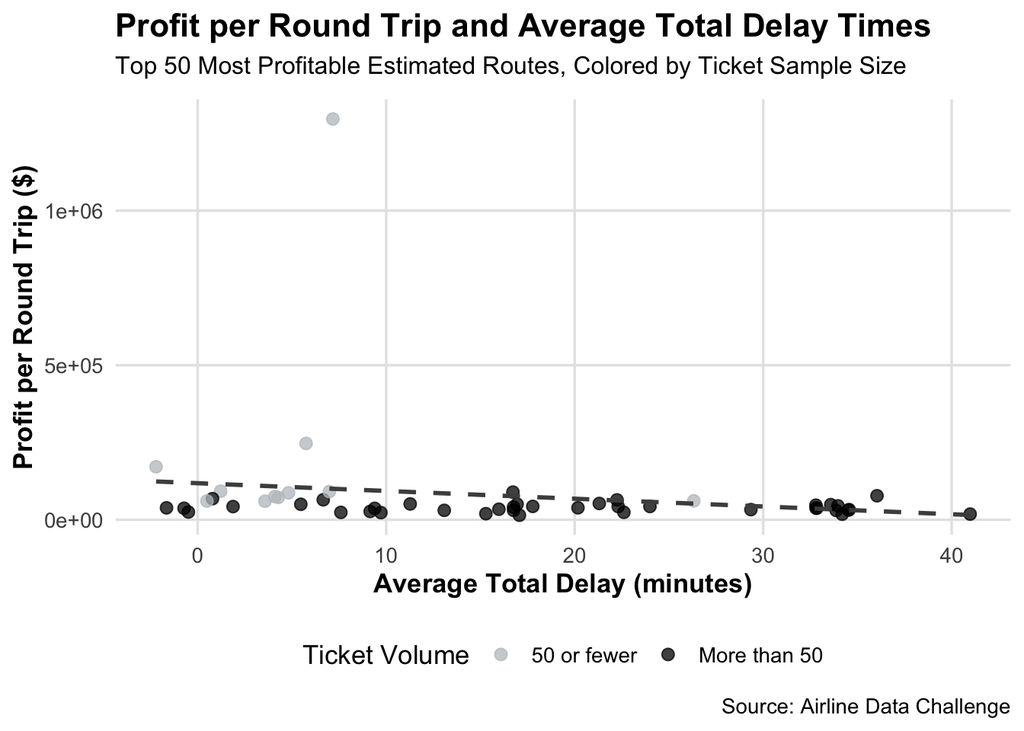

```r
#From the 10 flights of highest profitability, I recommend investing in round-trip flights for routes JFK ↔ LAX and ATL ↔ CLT, as the data for both round-trip options indicate an adequate sample size of ticket data for high confidence in profitability estimates, and average total delay per flight (the sum of expected departure and arrival delays) of less than 10 minutes. Although not within the top 10 most profitable estimated round trip options, I would also recommend ATL ↔ DCA (14th most profitable), HNL ↔ OGG (18th most profitable), and ATL ↔ MEM (20th most profitable). Although not within the top 10, these flights exhibit high ticket sample sizes for greater confidence in projected revenue, and low or exceptionally low average total delays of less than 10 minutes. Given the company's brand image emphasizing timeliness over other factors relative to competing airlines, it may be that pursuing only somewhat less profitable airlines that meet this standard will allow for greater ease of entry than may be expected from competing for only the most profitable projected round trips. Given unknown variables outside of the data, including anticipated strategic competitor response in terms of pricing power from larger, more established competitors, alternative means of quality competition from other airlines, and the potential for strategic diversification; this somewhat more conservative strategy may be more beneficial in the long-run.


library(ggplot2)

top_fifty_most_profitable_round_trips$Greater_Than_50_Ticket_Obs <- factor(top_fifty_most_profitable_round_trips$Greater_Than_50_Ticket_Obs, levels = c(0, 1), labels = c("50 or fewer", "More than 50"))

ggplot(top_fifty_most_profitable_round_trips, aes(x = Avg_Total_Delay_Time, y = PROFIT_PER_ROUND_TRIP, color = Greater_Than_50_Ticket_Obs)) +
  geom_point(alpha = 0.75, size = 2.5) +
  geom_smooth(method = "lm", se = FALSE, color = "gray30", linetype = "dashed") +
  scale_color_manual(
    values = c("50 or fewer" = "#BDC3C7", "More than 50" = "black")  # light gray vs. black
  ) +
  labs(
    title = "Profit per Round Trip and Average Total Delay Times",
    subtitle = "Top 50 Most Profitable Estimated Routes, Colored by Ticket Sample Size",
    x = "Average Total Delay (minutes)",
    y = "Profit per Round Trip ($)",
    color = "Ticket Volume",
    caption = "Source: Airline Data Challenge"
  ) +
  theme_minimal(base_size = 13) +
  theme(
    plot.title = element_text(face = "bold", size = 16),
    plot.subtitle = element_text(size = 12, margin = margin(b = 10)),
    axis.title = element_text(face = "bold"),
    panel.grid.major = element_line(color = "grey90"),
    panel.grid.minor = element_blank(),
    legend.position = "bottom"
  )
```

```r
#The first graphic generated below as result of ggplot2 above demonstrates how many apparent 'low delay time' route observations that initially may appear as highly profitable, may also be imprecise due to a small sample size. Thus, their high profitability could be attributed to variance or sampling error due to too few observations.
```

The first graphic generated above as result of ggplot2 above demonstrates how many apparent ‘low delay time’ route observations that initially may appear as highly profitable, may also be imprecise due to a small sample size. Thus, their high profitability could be attributed to variance or sampling error due to too few observations.

[figure not shown]

```r
ggplot(top_1000_most_profitable_round_trips, aes(x = PROFIT_PER_ROUND_TRIP)) +
  geom_histogram(binwidth = 10000, fill = "#3498DB", color = "white") +
  coord_cartesian(xlim = c(0, 100000)) +  # adjust range based on your data
  labs(title = "Distribution of Profit per Round Trip Among 1000 Most Profitable Routes with High Sampling",
       x = "Profit per Round Trip ($)",
       y = "Count") +
  theme_minimal()
```

The second graphic generated above as result of ggplot2 demonstrates that among the most profitable 1000 potential routes for roundtrip flight, although the top 10 may score highly, more than 10 routes demonstrate supranormal profit potential, and may be within seasonal sampling variance for profitability, placing them of potential alongside the top 10 routes by raw initial calculation.

#Task 4

`**The number of round trip flights it will take to breakeven on the upfront airplane cost for each of the 5 round trip routes that you recommend. Print key summary components for these routes.**`

```r
#For investigating the number of round trip flights given the selections to recoup plane costs, we may begin with a function for filtering for the recommended round trip routes:

filter_specific_roundtrip_routes <- function(df, selected_roundtrip_routes) {
  df %>%
    filter(ROUNDTRIP %in% selected_roundtrip_routes)
}


chosen_roundtrip_routes <- c("JFK ↔ LAX", "ATL ↔ CLT", "ATL ↔ DCA", "HNL ↔ OGG", "ATL ↔ MEM")
top_5_selected <- filter_specific_roundtrip_routes(top_twenty_most_profitable_round_trips, chosen_roundtrip_routes)


#Given plane cost for each route of $90 million:

Plane_Cost = 90000000

#Function to Calculate Roundtrips Necessary to Recoup Plane Costs:

top_5_selected <- top_5_selected %>%
  mutate(
    ROUNDTRIPS_FOR_BREAKEVEN = Plane_Cost/PROFIT_PER_ROUND_TRIP
  )

library(kableExtra)

kable(top_5_selected, "html", caption = "Final Five Recommended Routes") %>%
  kable_styling(
    bootstrap_options = c("striped", "hover", "condensed", "responsive"),
    full_width = FALSE,
    position = "center",
    font_size = 14
  )
```

Final Five Recommended Routes

| ORIGIN | DESTINATION | variable | statistic | value | ROUNDTRIP | ROUTE_KEY | AVG_DEP_DELAY | AVG_ARR_DELAY | AVG_AIR_TIME | AVG_DISTANCE | AVG_OCCUPANCY_RATE | OBSERVED_ROUND_TRIPS | NAME.x | ELEVATION_FT.x | CONTINENT.x | ISO_COUNTRY.x | MUNICIPALITY.x | COORDINATES.x | NAME.y | ELEVATION_FT.y | CONTINENT.y | ISO_COUNTRY.y | MUNICIPALITY.y | COORDINATES.y | Medium_Airport | Large_Airport | PROFIT | REVENUE | TOTAL_COST | … |
| --- | --- | --- | --- | --- | --- | --- | --- | --- | --- | --- | --- | --- | --- | --- | --- | --- | --- | --- | --- | --- | --- | --- | --- | --- | --- | --- | --- | --- | --- | --- |
| JFK | LAX | OBSERVATIONS | count | 876 | JFK ↔︎ LAX | JFK_LAX | 8.5438078 | -1.8848299 | 630.49793 | 4950 | 0.6500723 | 6320 | John F Kennedy International Airport | 13 | NA | US | New York | -73.77890015, 40.63980103 | Los Angeles International Airport | 125 | NA | US | Los Angeles | -118.4079971, 33.94250107 | 0 | 2 | 408441810 | 822028930 | 413587120 | … |
| ATL | CLT | OBSERVATIONS | count | 113 | ATL ↔︎ CLT | ATL_CLT | 5.7700254 | -0.3014342 | 88.05380 | 452 | 0.6488660 | 3076 | Hartsfield Jackson Atlanta International Airport | 1026 | NA | US | Atlanta | -84.428101, 33.6367 | Charlotte Douglas International Airport | 748 | NA | US | Charlotte | -80.94309997558594, 35.2140007019043 | 0 | 2 | 154108935 | 228392366 | 74283431 | … |
| ATL | DCA | OBSERVATIONS | count | 317 | ATL ↔︎ DCA | ATL_DCA | 6.9661667 | 2.4228263 | 165.75829 | 1094 | 0.6504267 | 3488 | Hartsfield Jackson Atlanta International Airport | 1026 | NA | US | Atlanta | -84.428101, 33.6367 | Ronald Reagan Washington National Airport | 15 | NA | US | Washington | -77.037697, 38.8521 | 0 | 2 | 129098479 | 233888184 | 104789705 | … |
| HNL | OGG | OBSERVATIONS | count | 112 | HNL ↔︎ OGG | HNL_OGG | -0.3392479 | -0.1579871 | 45.62779 | 200 | 0.6476319 | 4794 | Daniel K Inouye International Airport | 13 | NA | US | Honolulu | -157.924228, 21.32062 | Kahului Airport | 54 | NA | US | Kahului | -156.429993, 20.8986 | 1 | 1 | 120071132 | 200782916 | 80711784 | … |
| ATL | MEM | OBSERVATIONS | count | 83 | ATL ↔︎ MEM | ATL_MEM | 3.4505705 | -2.6674747 | 110.02725 | 664 | 0.6466225 | 1681 | Hartsfield Jackson Atlanta International Airport | 1026 | NA | US | Atlanta | -84.428101, 33.6367 | Memphis International Airport | 341 | NA | US | Memphis | -89.97669982910156, 35.04240036010742 | 0 | 2 | 114792113 | 158658682 | 43866569 | … |

#Task 5:

`**Key Performance Indicators (KPI’s) that you recommend tracking in the future to measure the success of the round trip routes that you recommend.**`

I would recommend tracking:

`**Change in Observed Round Trips per Quarter**` for selected and non-selected round trip routes, with or without standardized seasonality adjustments. Given that current profitability estimates depend on marginal profitability per round trip flight, relative increases/decreases in observed round trips per quarter for the chosen routes compared to alternatives demonstrate success/underperformance in profitability per flight with implications for the timeframe in recouping intial investment.

`**Average Occupancy Rate**` across selected and non-selected round trip routes, as this KPI would provide insight into performance both within the chosen route selections over time, and a potential point of comparison with alternative routes to measure competitive performance.

`**Average Depature Delay and Average Arrival Delay**` for selected round trip routes. These KPIs provide an essential performance measure key to the airline’s brand and reputation, especially with customers demonstrating higher loyalty, or frequent/business flight patterns. I believe it would be beneficial to track both KPIs per chosen route separately rather than only considering the sum of departure and arrival delays, as improved times for departure delays coinciding with worsened times for arrival delays or vice-versa could be masked by a KPI tracking sum of delays per route only.

#Final Notes

Given more time, I would be interested in more formally modeling the data using machine learning or econometric approaches. In particular, data on likelihood of cancellation remains underutilized, but may nonetheless be relevant to final recommendation if considered within the airline company ethic of “On time, for you”. The binary nature of cancellation would make it particularly amenable to more clearly interpretable predictive classifier models such as logistic regression. Detailed locational data furthermore could lead to pattern discovery in factors relating to geography and flight distance that may be highly relevant for determining estimates for final cost estimation.

[output not shown]